# BITMAP - Bitmap

https://www.spoj.com/problems/BITMAP/

There is given a rectangular bitmap of size n*m. Each pixel of the bitmap is either white or black, but at least one is white. The pixel in i-th line and j-th column is called the pixel (i,j). The distance between two pixels p1=(i1,j1) and p2=(i2,j2) is defined as:

d(p1,p2)=|i1-i2|+|j1-j2|.

Task:

Write a program which:

- reads the description of the bitmap from the standard input
- for each pixel, computes the distance to the nearest white pixel
- writes the results to the standard output.

### Solution:

Here I create square maps with changeable size and choosable ratio of white pixels for it. Then we create a new map that shows the distances of each pixel to the nearest white pixel with colors. The distance map will be a lot more visually interesting if the ratio of white/black pixels in low. The pyplot color map can also be changed as a function argument.  
To calculate the distances I simply look at every pixel, if it's white, the distance is 0, if not, we start look at the neighbors at 1, 2, .. distance and when a white pixel is found, we change the pixel's value to this distance on the distance map. Makes the job easier that there are less neighbors at closer distances and at longer distances there are linearly more and more. So for most pixels we actually don't have to check many neighboring pixels.  
Obviously the algorithm isn't very optimal this way though, as we check the same pixels again and again if they are white or not. But in the frame of this problem that doesn't really matter.

```python
#Pseudocode:

#create a random two color map
#what we can do is make white less likely with np.random.choice

#algorithm:
#for all pixel
#  dist = 0
#  while we dont find the nearest neighbor
#    for k in range(dist) 0-dist
#      get the coordinates of neighbor
#      check if white - if white, stop while loop and

#    dist += 1

#visualize new map
```

```python
import matplotlib.pyplot as plt
import numpy as np
```

```python
def bitmap(N, p_white, cmap=plt.cm.viridis):
    #randomly select white-1/black-0 pixels with required distribution and reshape the array to square form
    bmap = np.random.choice([0,1], size=N**2, replace=True, p=[1-p_white, p_white]).reshape(N, N)

    #algoritm
    newmap = np.zeros((N, N)) #a dist map same size as bmap, with zeroes so white pixels don't have to be changed

    #looking at every pixel in newmap
    for i in range(N):
        for j in range(N):
            if bmap[i, j] == 1: #if white, skip it (already labeled correctly)
                continue
            else:
                dist = 1
                found = False
                while found is False: #while closest white neighbor not found
                    #check every neighbor with larger and larger distances
                    #if not found with x distance, update the dist variable to x+1
                    for k in range(dist):
                        if (i-(dist-k) >= 0) & (j-k >= 0):
                            if bmap[i-(dist-k),j-k] == 1:
                                newmap[i,j] = dist
                                found = True
                        if (i-(dist-k) >= 0) & (j+k <= N-1):
                            if bmap[i-(dist-k),j+k] == 1:
                                newmap[i,j] = dist
                                found = True
                        if (i+(dist-k) <= N-1) & (j-k >= 0):
                            if bmap[i+(dist-k),j-k] == 1:
                                newmap[i,j] = dist
                                found = True
                        if (i+(dist-k) <= N-1) & (j+k <= N-1):
                            if bmap[i+(dist-k),j+k] == 1:
                                newmap[i,j] = dist
                                found = True
                        if (i-k >= 0) & (j-(dist-k) >= 0):
                            if bmap[i-k,j-(dist-k)] == 1:
                                newmap[i,j] = dist
                                found = True
                        if (i-k >= 0) & (j+(dist-k) <= N-1):
                            if bmap[i-k,j+(dist-k)] == 1:
                                newmap[i,j] = dist
                                found = True
                        if (i+k <= N-1) & (j-(dist-k) >= 0):
                            if bmap[i+k,j-(dist-k)] == 1:
                                newmap[i,j] = dist
                                found = True
                        if (i+k <= N-1) & (j+(dist-k) <= N-1):
                            if bmap[i+k,j+(dist-k)] == 1:
                                newmap[i,j] = dist
                                found = True
                    dist += 1

    #show the two maps next to each other with subplots and imshow
    fig, axs = plt.subplots(ncols=2, figsize=(16, 8))
    axs[0].imshow(bmap, cmap = plt.cm.gray)
    axs[1].imshow(newmap, cmap = cmap)

    return None
```

Some examples with different map size, ratio of white pixels and color maps:

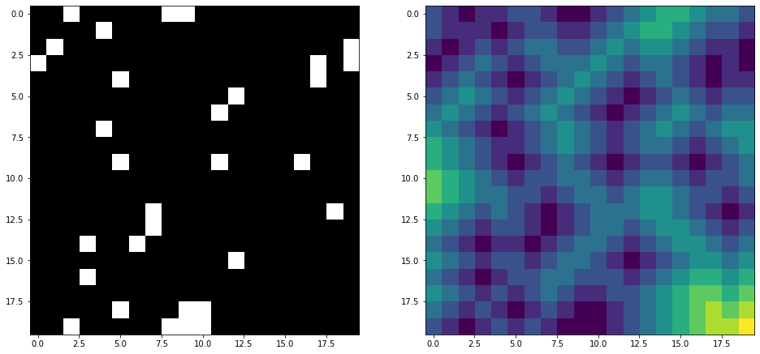

```python
bitmap(20, 0.1)
```

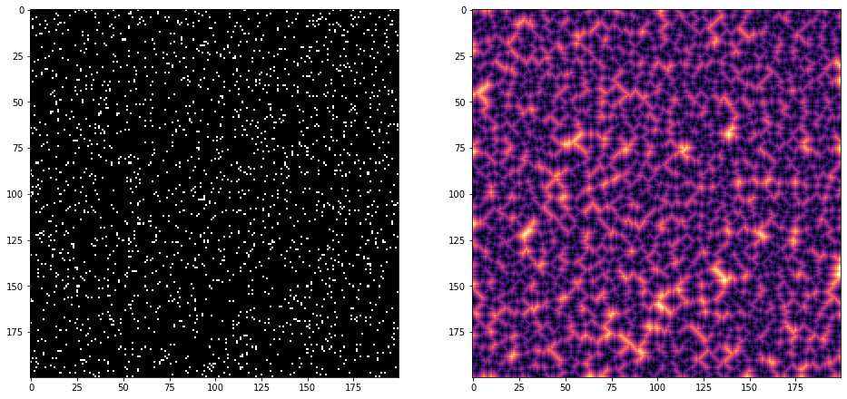

```python
bitmap(200, 0.05, plt.cm.magma)
```

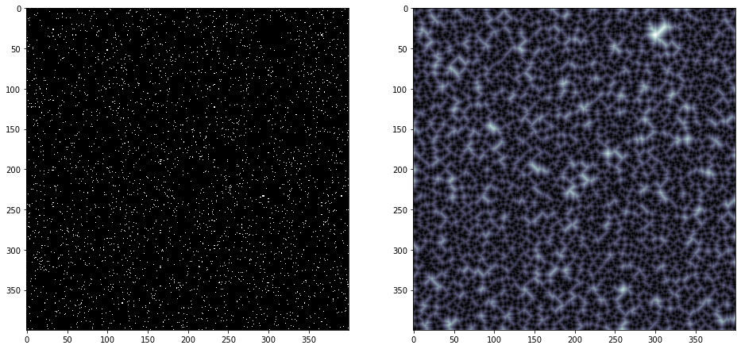

```python
bitmap(400, 0.02, plt.cm.bone)
```

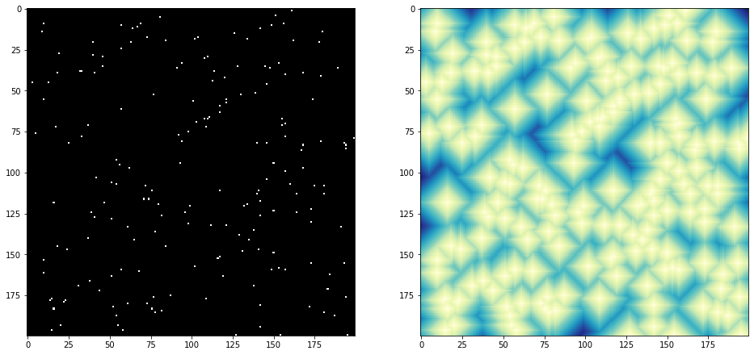

```python
bitmap(200, 0.005, plt.cm.YlGnBu)
```